# HG4052 / HG7034 · Week 13: Poster Fair

HG4052 / HG7034 · Poster Fair

Jump to a slide · M or O toggles · Esc closes

[figure not shown]

HG4052 / HG7034 · Speech Synthesis & Recognition / Week 13

# Poster Fair.

A mini conference on synthetic voices.

Fri 13 Nov 2026 · TR69 21 poster pitches Career Panel: Ezio Xie

Chenzi Xu · chenzi.xu@ntu.edu.sg

You paid for the kopi?

[figure not shown]

→ / space to advance · F for fullscreen · M for the slide menu

★

The program · Fri 13 Nov 2026 · TR69

## Today is a mini conference

09:40

Warm-up

The table trick from Quiz 2

One more look at how the table finds the best path

a few minutes

09:45

Career Panel

My journey through linguistics

Ezio Xie (Founder, PDP Limited): panel sharing + Q&A

45–60 min

about10:45

Poster pitches

21 posters, 3 minutes each

Quick rotation: one voice after another

about 75 min

about12:00

Closing reception

Food and chat

Chat with the presenters

informal

?

Quiz 2, B1 · the question

## One table, three rules

The word “see”: two states, and what each arrow costs

Emission probabilities: how well each frame fits each state

ON THE PAPER

**(a)(i)** Fill in the Viterbi table. The word ends after frame 3, so do not count the transition out of /i/. [2]

**(a)(ii)** Give the best path and its probability. [1]

**(b)** When several routes arrive at the same cell, what do Viterbi and the CTC forward table put there, and why? [2]

**(c)(i)** Forced alignment fills the same kind of table, with the transcript already known. What does it already know, and what does it give you? [1]

**(d)** All three methods fill a table. What is the benefit of that? [1]

↘

Quiz 2, B1(c) and (d) · the same table in forced alignment

## Forced alignment: the path only steps down

The word “kopi”: four phones, ten frames

Made-up probabilities. Simplified: one state per phone; real aligners use about three per phone and allow optional pauses between words.

- Rows: the transcript’s phones, in order
- Each frame: stay, or step down one
- Column 1 is 0 except the first phone
- What we find: the boundaries

B1(d) · WHAT THE TABLE SAVES

THE QUIZ WAS ONE

V

Quiz 2, B1(a)(i) · one cell at a time

## Each cell keeps the best route into it

**V(s, t)** = P(x<sub>t</sub> | s) × max over routes of [ **V(prev, t−1)** × P(prev → s) ]

**V(s, t)**: the probability of the best path that ends in state s at frame t

**a route**: one cell one frame back, times the transition out of it

**max**: keep the biggest route, remember where it came from, discard the rest

Colors, in every figure today

● /s/ ● /i/ ● the route kept, and the best path ● the route discarded

×

Quiz 2, B1(a)(i) · the last column

## Compare the routes, not the cells

Two routes arrive at /i/ in frame 3

- 0.18 is the larger cell, and it loses: its transition is the smaller one
- A route is a cell **times** the transition out of it, so both parts count
- Keep 0.06, and remember that it came from /s/

WHAT THIS COSTS

Comparing the cells instead of the routes gives 0.0216 and the path /s/ → /i/ → /i/. It was the most common wrong answer, and it scored nothing on (a)(ii).

←

Quiz 2, B1(a)(ii) · reading the answer off

## Follow the kept routes, not the maxima

- Start at the cell the word has to end in, then follow the route each cell kept
- A cell holds the best path **into** it, and those paths need not agree with each other

WHY 0.008 AND NOT 0

V(/s/, 3) scores the best route into that cell, and a cell knows nothing about what follows it. The end-in-/i/ rule applies when you read the answer off, not while you fill the table: with a fourth frame, /s/ is live again.

→

A question from the room

## A word model only runs forward

The word model

An arc from /i/ back to /s/ would mean the pronunciation went /s i s/, which is a different word. The rows also leave no room for it: 0.4 + 0.6 and 0.3 + 0.7 already come to 1.

The ice-cream model

Hot and cold can follow each other in any order, so every arc exists and the matrix is full. Nothing fixes the sequence in advance.

What is still shared

The same recursion, the same table, the same backtrace. Only the set of allowed arcs differs, and that is what the word's spelling buys you.

1

Quiz 2, B1 · what the table buys you

## One table does the work of every path

WHY THE REUSE IS SAFE

Nothing is approximated: what comes next depends only on the state a path is in, not on the way in, so a dropped route could never have won later.

2

Quiz 2, B1(b) to B1(d) · the same table, four uses

## Keep the best route, or add them all

Viterbi decoding(the quiz)

Forced alignment

Unit selection

CTC forward

Known in advance

the frames

the frames and the phones

the units the text needs

the frames and the transcript

What is searched

the state sequence

the timing

a recording for each unit

no single path: all alignments

Columns

frames

frames

target units

frames

Rows

states

phones, in order

candidate recordings

tokens, with blanks

Allowed moves

the model’s arcs

stay, or step down one

any row to any row

stay, step down, skip a blank

In each cell

**multiply, keep the largest**

**multiply, keep the largest**

**add costs, keep the smallest**

**multiply, add them all**

Read off

the path

the boundaries

the recordings to splice

the transcript’s probability

cost = −log probability

Adding costs and keeping the smallest picks the same route as multiplying probabilities and keeping the largest. Unit selection keeps the best route like Viterbi; it just counts in costs, and any recording can follow any other.

[figure not shown]

Career Panel · 09:45

# My journey through linguistics.

Panel sharing + Q&A

Ezio Xie

Founder, PDP Limited · 45–60 minutes

[figure not shown]

Career Panel · meet our guest

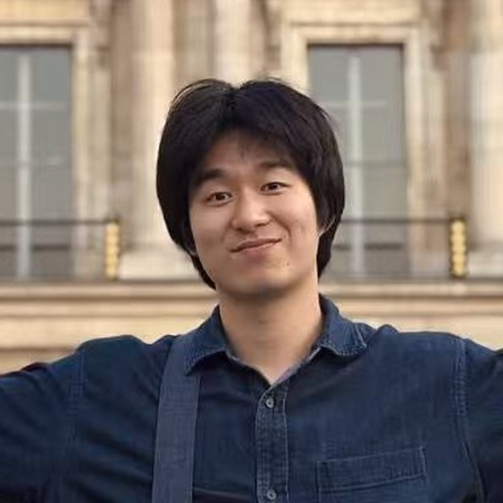

Our guest!

## Ezio Xie.

Founder, PDP Limited

Researcher in Linguistics and Computation

Education

MPhil in Linguistics

University of Oxford

[figure not shown]

?

Career Panel · Q&A

## Ask Ezio anything

Question starters, if you need one:

What from your linguistics degree do you use most often?

You speak many languages. What motivates you to learn more?

What challenges did you face moving from linguistics into tech?

What does a typical week look like for you now?

[figure not shown]

Next · about 10:45

# Poster pitches.

21 posters · 3 minutes each · quick rotation

Poster pitches · how it runs

## Rules for the pitch

1

3 minutes

Hard stop at the chime

2

Poster up

Audio ready to play

3

Next up?

Be ready to go

4

Applause

For every voice

Tonight, 23:59: abstract and poster on NTULearn

[figure not shown]

Poster pitches · running order

## The pitch clock

3:00

ready

chime at 0:00

Now Poster 1 1 of 21

Next Poster 2

**Enter** start or pause · **N** next pitch · **B** back · **R** reset · click a name to jump

[figure not shown]

Poster pitches · your vote

## Vote: best pitch and best poster

Best pitch

The three minutes you remember

Best poster

The poster that taught you most

A number and a short reason for each · not your own

Closing · the course in one slide

## Speech technology keeps coming back to linguistics

Rules

1950s–1980s

Formant synthesis, hand-written rules

Linguists write the rules

Statistics

1990s–2000s

HMMs, n-grams, unit selection

Phone sets, lexicons, labels

Neural

2010s

CTC, attention, neural vocoders

Data replaces the rules

Speech LLMs

2020s

Codec models, few-second cloning

Fluent, but whose speech?

Next

now

Linguistics of and with speech models

Linguists test, explain, repair

What you showed today

Minimal pairs, not scores

Plain against Singapore English, everything else fixed

A variety, not an error

Particles flattened to a full stop; local words and names anglicized

Ears, not just metrics

WER rose on local words while predicted naturalness stayed flat; clones sounded like the speaker without speaking like them

Closing · today’s posters as a research agenda

## Six directions for the linguistics of speech technology

Language varieties and representational fairness

Are varieties modeled as systems in their own right, or as noise around a standard?

Seen today: 2, 8, 9, 10, 11, 17

Prosodic and pragmatic competence

Can a system map meaning onto intonation, focus and discourse particles?

Seen today: 12, 13, 14, 15, 16, 18

Diagnostic evaluation

Minimal pairs and expert listening that explain a capability, not a score

Speaker identity and consent

What a voice clone preserves, what it loses, and who may authorize it

Multilingual and code-switched speech

Loanwords, mixed-language utterances and low-resource languages

Linguistically informed interpretability

Where are phones, tones and stress represented inside the network?

Open: no poster yet

Numbers are today’s pitches. Framing inspired by an EMNLP 2026 keynote on the linguistics of LLMs.

[figure not shown]

HG4052 / HG7034 · the last session

# Thank you.

To Ezio, to all 21 presenters, and to all of you.

Closing reception: food and chat, now

Tonight, by 23:59: abstract and poster on NTULearn

Makan time lah!

[figure not shown]